# Plotting more complicated pedigrees with `ggPedigree()`

# Introduction

This vignette demonstrates some of the more complex family trees you can visualization with `ggPedigree()`.

We illustrate usage with a more complicated data set from BGmisc:

- `asoiaf` – extended Targaryen family

# Basic usage

```r
library(ggpedigree) # ggPedigree lives here
library(BGmisc) # helper utilities & example data
library(ggplot2) # ggplot2 for plotting
library(viridis) # viridis for color palettes
library(tidyverse) # for data wrangling
```

## Load Packages and Data

We begin by loading the required libraries and examining the structure of the built-in `ASOIAF` pedigree.

```r
data(ASOIAF)
```

The ASOIAF dataset includes character IDs, names, family identifiers, and parent identifiers for a subset of characters drawn from the *A Song of Ice and Fire* canon.

```r
head(ASOIAF)
```

```
#>   id famID momID dadID          name sex
#> 1  1     1    NA    NA   Walder Frey   M
#> 2  2     1    NA    NA   Perra Royce   F
#> 3  3     1     2     1  Stevron Frey   M
#> 4  4     1     2     1    Emmon Frey   M
#> 5  5     1     2     1    Aenys Frey   M
#> 6  6     1    NA    NA Corenna Swann   F
```

# Data Cleaning

```r
df_got <- checkSex(ASOIAF,
  code_male = "M",
  code_female = "F",
  repair = TRUE
)


# Find the IDs of Jon Snow and Daenerys Targaryen

jon_id <- df_got %>%
  filter(name == "Jon Snow") %>%
  pull(ID)

dany_id <- df_got %>%
  filter(name == "Daenerys Targaryen") %>%
  pull(ID)
```

Here we’ve added phantom IDs to the dataset, which are used to represent individuals who are not directly related to the family tree but are still part of the pedigree structure. This is useful for visualizing complex relationships, such as half-siblings or step-siblings.

```r
df_repaired <- checkParentIDs(df_got,
  addphantoms = TRUE,
  repair = TRUE,
  parentswithoutrow = FALSE,
  repairsex = FALSE
) %>% mutate(
  famID = 1,
  affected = case_when(
    ID %in% c(jon_id, dany_id, "365") ~ 1,
    TRUE ~ 0
  )
)
```

```
#> REPAIR IN EARLY ALPHA
```

## Visualize the Pedigree with `plotPedigree()`

Here is the classic pedigree plot of the Targaryen family, with Jon Snow and Daenerys Targaryen highlighted in black The `plotPedigree()` function from {BGmisc} provides a quick way to visualize the pedigree structure. It serves as a wrapper function from {kinship2} and is useful for quickly checking the pedigree structure.

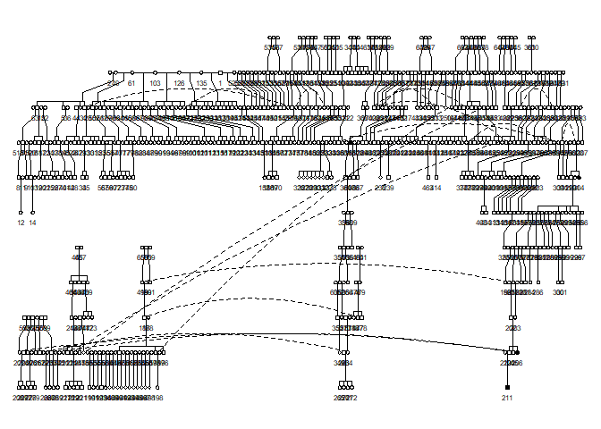

```
#> Did not plot the following people: 85 88 125 142 228 229 258 259 274 275 305 336 357 381 388 405 409 418 420 424 428 451 487
#> named list()
```

```r
plotPedigree(df_repaired,
  affected = df_repaired$affected,
  verbose = FALSE
)
```

## Visualize the Pedigree with `ggPedigree()`

Here is the same pedigree, but using `ggPedigree()` from {ggpedigree}. This function provides a more flexible and customizable way to visualize pedigrees, allowing for easy integration with other `ggplot2` functions.

```r
ggPedigree(df_repaired,
  status_col = "affected",
  personID = "ID",
  config = list(
    unaffected = 0,
    sex_color = FALSE,
    code_male = "M",
    affected = 1,
    affected_shape = 4,
    point_size = 3,
    spouse_segment_color = "pink",
    sibling_segment_color = "blue",
    parent_segment_color = "green",
    offspring_segment_color = "black",
    self_segment_color = "purple",
    ped_width = 14
  )
)
```

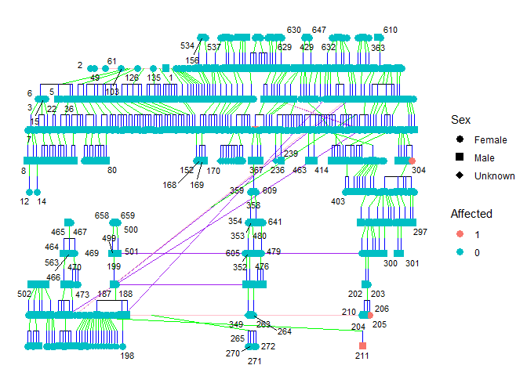